# Aprendizaje automático con criterio humano: restricciones monotónicas para decisiones consistentes

Gestión de datos en organizaciones - 4to encuentro interdisciplinar

Karina A. Bartolomé

Especialista en Métodos Cuantitativos para la Gestión y Análisis de Datos en Organizaciones (FCE, UBA). Lic. en Economía (FCE, UNLP). Líder técnica de Ciencia de Datos (Ualá).

2026-09-03

## 0.1 Consideraciones previas

- Se recomienda contar con conocimientos previos de modelos de aprendizaje automático y programación (python).
- Todo el código se encuentra disponible en [Repositorio](https://github.com/karbartolome/workshops)
- El contenido de estas diapositivas está disponible para ejecutar en [Google colab](https://drive.google.com/file/d/1S-CDufFiGUhzRMEM0LTWrUx_nmaSFl_O/view?usp=sharing)
- Durante el seminario se utilizarán los siguientes paquetes:

📦 `numpy` = 1.26.4  
📦 `pandas` = 2.2.3  
📦 `scikit-learn` = 1.5.2  
📦 `matplotlib` = 3.9.2  
📦 `seaborn` = 0.13.2

**Environment**: `ds_model/v1.0`  
**Python**: `3.12.13`

# 1 Aprendizaje automático

## 1.1 Modelos predictivos

Un modelo de *machine learning* busca aprender una relación entre un conjunto de variables explicativas (X) y una variable objetivo (y) para predecir el valor de y a partir de X .

$$\color{orange}{y} = \color{black}{f}\left(\color{blue}{\mathbf{X}}\right),
\qquad
\mathbf{X} = (X_1, X_2, \ldots, X_p)$$

Existen múltiples tipos de modelos de aprendizaje automático, cada uno con diferentes niveles de complejidad y flexibilidad. A medida que aumenta la flexibilidad, puede mejorar la capacidad predictiva, pero resulta más difícil **controlar o interpretar cómo cada variable afecta la predicción**.

Tabla 1: Flexibilidad vs interpretabilidad. Adaptado de la Fig. 2.7 (James et al. 2023)

| Método | Flexibilidad | Interpretabilidad |
| --- | --- | --- |
| Mínimos cuadrados | Lineal, poco flexible | Alta |
| Árboles de decisión | No lineal, por partes | Media/Alta |
| Bagging/Boosting | No lineal, flexible | Media/Baja |
| Deep Learning | No lineal, altamente flexible | Baja |

## 1.2 Actores involucrados

Ciclo de vida de modelos predictivos:

```
%%{init: {'flowchart': {'curve': 'linear'}}}%%

graph LR
    datos[Datos]
    modelo[Modelo]
    prediccion[Predicción]
    decision[Decisión]
    impacto[Impacto]:::focus

    datos --> modelo --> prediccion --> decision --> impacto
    impacto -.-> datos

    classDef focus fill:#BDCBCC,stroke:#333,stroke-width:3px,color:black;
```

Figura 1: Ciclo de vida de un modelo predictivo

Donde intervienen diversos actores (Molnar 2025):

- **Data subjects**: aportan los datos utilizados para entrenar el modelo.
- **Creadores**: desarrollan y entrenan el modelo.
- **Ejecutores**: toman decisiones a partir de sus predicciones.
- **Operadores**: interactúan directamente con el sistema (implementan las decisiones).
- **Decision subjects**: reciben las consecuencias de esas decisiones.
- **Auditores**: evalúan, investigan y controlan el funcionamiento del sistema.

## 1.3 Modelos basados en árboles

Los árboles de decisión pueden utilizarse individualmente o combinarse para construir modelos más potentes.

```
%%{init: {'flowchart': {'curve': 'linear'}}}%%

graph LR
    trees[Modelos basados<br/>en árboles]
    single[Árbol individual<br/><i>Decision Tree</i>]
    ensembles[Ensambles]
    bagging[Bagging<br/><i>Random Forest</i>]
    boosting[Boosting]:::focus
    models[<i>XGBoost<br/>LightGBM<br/>CatBoost<br/>HistGradientBoosting</i>]:::focus

    trees --> single
    trees --> ensembles
    ensembles --> bagging
    ensembles --> boosting
    boosting --> models

    classDef focus fill:#BDCBCC,stroke:#333,stroke-width:3px,color:black;
```

Figura 2: Principales tipos de modelos basados en árboles

## 1.4 Modelos de boosting

Los modelos de *boosting* combinan múltiples modelos secuencialmente, donde cada nuevo modelo busca reducir los errores del modelo acumulado anterior. Matemáticamente<sup>1</sup>:

$$\underbrace{\color{orange}{\widehat{y}_i^{(M)}}}_{\color{orange}{\text{predicción final}}}
=
\sum_{m=1}^{M}
\underbrace{\color{blue}{\eta}}_{\color{blue}{\text{tasa de aprendizaje}}}
\,
\underbrace{\color{red}{f_m(x_i)}}_{\color{red}{\text{modelo simple}}}
\qquad(1)$$

Donde cada $\color{red}{f_m}$ es un modelo simple (*weak learner*, por ejemplo un árbol de decisión) y $\color{blue}{\eta}$ controla cuánto contribuye cada nuevo modelo al ensamble.

En cada iteración, se incorpora el modelo que minimiza la pérdida del modelo actualizado <sup>2</sup>:

$$f_m
=
\underset{f}{\operatorname{argmin}}\;
\sum_{i=1}^{n}
\underbrace{\color{teal}{L}}_{\color{teal}{\text{función de pérdida}}}
\left(
\underbrace{\color{purple}{y_i}}_{\color{purple}{\text{valor observado}}},
\,
\underbrace{\color{orange}{\widehat{y}_i^{(m-1)}}}_{\color{orange}{\text{predicción anterior}}}
+
\underbrace{\color{red}{f(x_i)}}_{\color{red}{\text{modelo simple}}}
\right)
\qquad(2)$$

**Varios algoritmos de boosting permiten incorporar restricciones monotónicas sobre las predicciones.**

[^1]: Adaptado de la formulación general de Forward Stagewise Additive Modeling (Hastie, Tibshirani, y Friedman 2009, Algoritmo 10.2), y de Andrei (2026)
[^2]: Versión simplificada, en la práctica, este proceso se realiza mediante métodos basados en el gradiente de la función de pérdida.

# 2 Interpretabilidad de modelos

## 2.1 XAI: Explainable AI

La **Inteligencia Artificial Explicable (XAI)** reúne métodos y técnicas que permiten describir el comportamiento de un modelo y comunicar por qué produce una predicción determinada (Molnar 2025).

Una explicación debería ayudar a una persona a:

- **Entender** qué variables influyen en el modelo y en qué dirección.
- **Evaluar** si la predicción es razonable y consistente con el conocimiento de dominio.
- **Detectar** errores, sesgos o comportamientos inesperados.
- **Auditar** el sistema y justificar una decisión ante otras personas.

## 2.2 XAI: Explainable AI (Cont.)

Los métodos que se aplican después de entrenar el modelo pueden clasificarse en dos categorías (Molnar 2025):

- **Métodos globales**: describen el comportamiento promedio del modelo sobre todo el dataset.
  - **Dependencia parcial (PDP)**: muestra el efecto promedio de una variable sobre la predicción.
  - **Importancia de variables (*permutation feature importance*)**: mide cuánto empeora el modelo al permutar una variable.
- **Métodos locales**: explican una predicción individual.
  - **Ceteris paribus**: muestran cómo cambia una predicción particular al modificar una variable.
  - **LIME**: aproxima el modelo localmente con un modelo simple e interpretable.
  - **Valores de Shapley / SHAP**: reparten una predicción individual entre las variables de forma aditiva. Al agregar muchas explicaciones locales (ej. *summary plot*) se obtiene también una vista global.

> Una explicación describe el comportamiento del modelo; no necesariamente representa una relación causal del mundo real.

## 2.3 Interpretabilidad en modelos de Machine Learning

Quienes toman decisiones necesitan entender cómo funciona el modelo para confiar en él y tomar decisiones consistentes con su conocimiento de dominio.

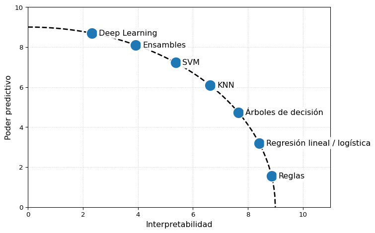

Figura 3: Trade-off interpretabilidad vs. poder predictivo, adaptado de la Fig. 1 (Gunning y Aha 2019)

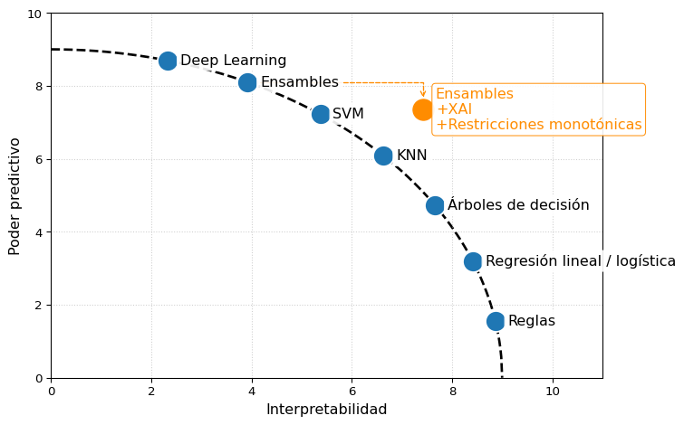

Figura 4: Trade-off interpretabilidad vs. poder predictivo con XAI y restricciones monotónicas

## 2.4 Interpretabilidad en modelos de Machine Learning (Cont.)

Al desarrollar modelos de *Machine Learning*, en general se cuenta con conocimiento sobre el problema que se busca modelar.

Ejemplos:

- **Predicción de precios de propiedades**: Manteniendo el resto de las variables constantes, a mayor superficie ($m^2$), mayor precio.
- **Scoring crediticio**: Manteniendo el resto de las variables constantes, a mayor cantidad de meses con buen comportamiento, menor probabilidad de default.
- **Seguros**: Manteniendo el resto de las variables constantes, a mayor antigüedad del vehículo, mayor probabilidad de falla mecánica.

Las explicaciones de un modelo deberían ser consistentes con las expectativas y conocimientos previos de sus usuarios (Molnar 2025). Sin embargo, los modelos pueden aprender relaciones que contradicen estas expectativas. Una forma de incorporar conocimiento de dominios es mediante `restricciones monotónicas`.

# 3 Restricciones monotónicas

## 3.1 Monotonicidad

¿Qué es la monotonicidad?

- Una función es **monotónica creciente** si, cuando aumenta el valor de entrada, su salida no disminuye:
  - `Si x1 <= x2: f(x1) <= f(x2)`
- Una función es **monotónica decreciente** si, cuando aumenta el valor de entrada, su salida no aumenta:
  - `Si x1 <= x2: f(x1) >= f(x2)`

En machine learning, una **restricción monotónica** fuerza al modelo a respetar una dirección esperada entre una variable y la predicción.

## 3.2 Monotonicidad creciente

La función `f(x) = x ** 2` es monotónica creciente para valores de `x >= 0`: si `x` aumenta, `f(x)` también aumenta o se mantiene igual.

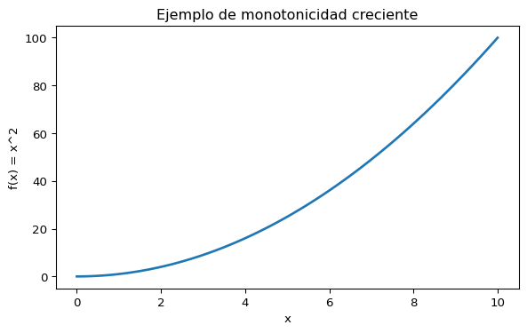

Figura 5: Ejemplo de monotonicidad creciente

## 3.3 Monotonicidad decreciente

La función `f(x) = exp(-x)` es monotónica decreciente: si `x` aumenta, `f(x)` disminuye.

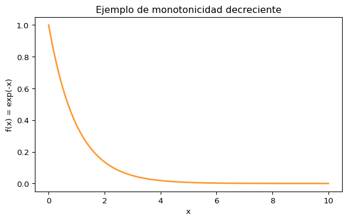

Figura 6: Ejemplo de monotonicidad decreciente

## 3.4 Modelos de boosting con restricciones monotónicas

Sea $c_j \in \{-1, +1\}$ el sentido de la restricción para la variable $x_j$:

- $c_j = -1$: restricción decreciente
- $c_j = +1$: restricción creciente

Refiriéndose a la ecuación Ecuación 1, para garantizar que el modelo respete la monotonía en la variable $x_j$, se requiere que el nuevo árbol $f_m$ satisfaga:

Para dos observaciones $i, k$, si $x_{i,j} \leq x_{k,j}$ y $x_{i,-j} = x_{k,-j}$, entonces:

$$c_j \cdot f_m(x_i) \leq c_j \cdot f_m(x_k)$$

Es decir, el árbol debe ser monotónico en la variable $x_j$ con la dirección especificada por $c_j$.

En cada iteración, el nuevo árbol se busca únicamente dentro del conjunto restringido $F_{\text{mono}}$ de árboles que cumplen esta propiedad:

$$f_m
=
\underset{f \, \in \, F_{\text{mono}}}{\operatorname{argmin}}\;
\sum_{i=1}^{n}
\underbrace{\color{teal}{L}}_{\color{teal}{\text{función de pérdida}}}
\left(
\underbrace{\color{purple}{y_i}}_{\color{purple}{\text{valor observado}}},
\,
\underbrace{\color{orange}{\widehat{y}_i^{(m-1)}}}_{\color{orange}{\text{predicción anterior}}}
+
\underbrace{\color{red}{f(x_i)}}_{\color{red}{\text{nuevo árbol}}}
\right)
\qquad(3)$$

donde $F_{\text{mono}} = \left\{ f : c_j \cdot f(x_i) \leq c_j \cdot f(x_k) \text{ si } x_{i,j} \leq x_{k,j}, \, \forall i,k,j \right\}$

## 3.5 Ejemplo simple

**Datos simulados**

```python
# Simulación de N observaciones:
rng = np.random.default_rng(42)
n = 1_000

# Feature: distribución uniforme entre 18 y 70 años
feature = rng.uniform(18, 70, n)

# Probabilidad base: target=1 decrece con la feature
p = 0.90 - 0.0105 * (feature - 18)

# Ruido en toda la distribución
noise = rng.normal(0, 0.07, n)

# Ruido extra entre 50 y 60 años
high_noise = np.where(
    (feature >= 50) & (feature <= 60),
    rng.normal(0, 0.18, n),
    0
)

# Probabilidad final
p = np.clip(p + noise + high_noise, 0.02, 0.98)

# Variable objetivo binaria
target = rng.binomial(1, p)

df = pd.DataFrame({
    "feature": np.round(feature, 1),
    "target": target
})
X = df[["feature"]]
y = df["target"]
```

Se utilizan datos simulados para ilustrar el efecto de imponer una restricción monotónica en un modelo de clasificación binaria. El dataset contiene 1000 observaciones y 2 columnas: `feature` y `target` (variable binaria: 0 o 1).

Tabla 2: Datos simulados (muestra de 4 observaciones)

| target | feature |
| --- | --- |
| 1 | 61.5 |
| 1 | 50.3 |
| 0 | 54.9 |
| 0 | 35.3 |

## 3.6 Ejemplo simple (Cont.)

Supuesto: dado el conocimiento de dominio de este tipo de datos, se espera que la probabilidad del evento `target` disminuya a mayor valor de la variable `feature` pero esa relación no sea estrictamente monotónica en los datos de la muestra.

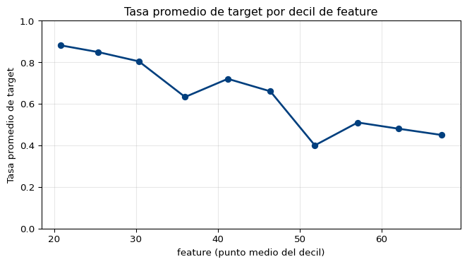

Figura 7: Tasa promedio de target por decil de feature

## 3.7 Modelo con restricciones monotónicas

Se ajustan 2 modelos:

- Modelo estándar (sin restricción monotónica)

**Modelos con y sin restricción monotónica**

```python
# Modelo sin restricción monotónica
modelo_sin_restriccion = HistGradientBoostingClassifier(
    max_depth=3, max_iter=2, learning_rate=0.7, random_state=42
)
modelo_sin_restriccion.fit(X, y)
```

```
HistGradientBoostingClassifier(learning_rate=0.7, max_depth=3, max_iter=2,
                               random_state=42)
```

- Modelo con restricción monotónica decreciente sobre la variable `feature`

**Modelo con restricción monotónica**

```python
# Se genera una copia del modelo anterior:
modelo_con_restriccion = deepcopy(modelo_sin_restriccion)

# Se añade una restricción monotónica decreciente sobre la variable `feature`:
modelo_con_restriccion.set_params(monotonic_cst={"feature": -1})
modelo_con_restriccion.fit(X, y)
```

```
HistGradientBoostingClassifier(learning_rate=0.7, max_depth=3, max_iter=2,
                               monotonic_cst={'feature': -1}, random_state=42)
```

## 3.8 Modelo con restricciones monotónicas (Cont.)

`HistGradientBoostingClassifier` almacena los árboles que componen el modelo (internamente como `TreePredictor`). Se utiliza una función para visualizar los 2 árboles (`max_iter=2`) que componen cada uno de los modelos ajustados.

- Sin restricción
- Con restricción

**Árboles del modelo sin restricción monotónica**

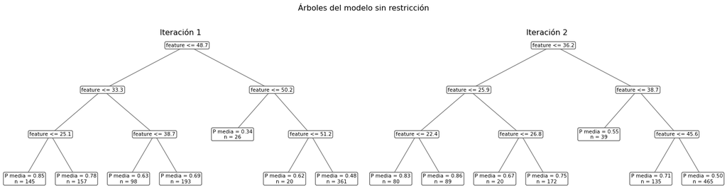

Figura 8

```python
from utils.plot_trees import plot_hist_gradient_boosting_tree

fig, axes = plt.subplots(1, modelo_sin_restriccion.max_iter, figsize=(16, 4))
for iteration, ax in enumerate(np.atleast_1d(axes)):
    plot_hist_gradient_boosting_tree(
        modelo_sin_restriccion,
        iteration,
        feature_names=["feature"],
        X_reference=X,
        ax=ax,
    )
fig.suptitle("Árboles del modelo sin restricción", y=1.02)
plt.tight_layout()
plt.show()
```

**Árboles del modelo con restricción monotónica**

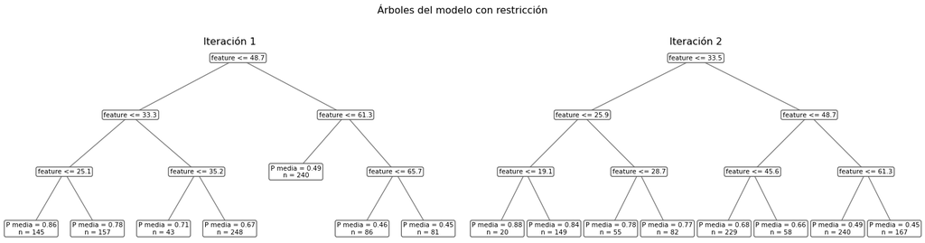

Figura 9

```python
fig, axes = plt.subplots(1, modelo_con_restriccion.max_iter, figsize=(16, 4))
for iteration, ax in enumerate(np.atleast_1d(axes)):
    plot_hist_gradient_boosting_tree(
        modelo_con_restriccion,
        iteration,
        feature_names=["feature"],
        X_reference=X,
        ax=ax,
    )
fig.suptitle("Árboles del modelo con restricción", y=1.02)
plt.tight_layout()
plt.show()
```

## 3.9 Modelo con restricciones monotónicas (Cont.)

En la Figura 10 se comparan las predicciones de los modelos con y sin restricción monotónica decreciente sobre la variable `feature`. La **dependencia parcial** muestra cómo cambia, en promedio, la predicción cuando se modifica una variable manteniendo el resto de las variables constantes:

- **Modelo sin restricción**: la probabilidad aumenta en ciertos valores (contraintuitivo, se espera que disminuya con la `feature`).
- **Modelo con restricción**: respeta la relación esperada entre la `feature` y la probabilidad.

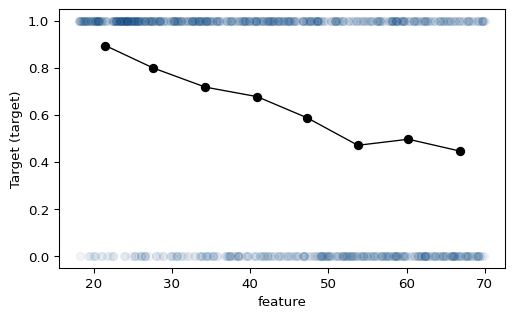

(a) Datos observados

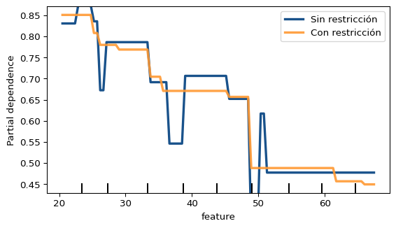

(b) Dependencia parcial

Figura 10: Comparación de modelos con y sin restricción monotónica

# 4 Caso: Give me some credit (Kaggle)

## 4.1 Datos

Give me some credit (Fusion y Cukierski 2011) es un dataset con información financiera y demográfica de individuos. El objetivo es modelar el riesgo de incumplimiento a partir de esas características. Caso ilustrativo por su valor didáctico y reproducibilidad. No representa necesariamente las variables ni modelos utilizados en sistemas reales.

**Lectura de datos**

```python
df = pd.read_csv(f"{PATH_DATA}/cs-training.csv").drop("Unnamed: 0", axis=1)

df["DebtRatio"] = df["DebtRatio"].clip(0, 1)

TARGET = "SeriousDlqin2yrs"
FEATURES = [
    "DebtRatio",
    "age",
    "MonthlyIncome",
    "NumberOfOpenCreditLinesAndLoans"
]

df = df[FEATURES + [TARGET]]
X = df.drop(TARGET, axis=1)
y = df[TARGET]

X_train, X_test, y_train, y_test = train_test_split(
    X, y, test_size=0.3, random_state=42, stratify=y
)
```

Se cuenta con un dataset de 150000 observaciones y 5 variables:

- 105000 observaciones en el dataset de entrenamiento
- 45000 en el dataset de evaluación.

Se busca responder los siguientes interrogantes:

- ¿Cuál es la probabilidad de *default* de un individuo dadas ciertas características?
- ¿Cómo cambia esa probabilidad para un individuo si aumenta una variable, manteniendo el resto de las variables constantes?

## 4.2 Análisis exploratorio de datos

Resumen Comparativo de Variables

Valores expresados como Mediana [Q1 - Q3]

| Variable | SeriousDlqin2yrs=0 | SeriousDlqin2yrs=1 |
| --- | --- | --- |
| DebtRatio | 0.36 [0.17 - 0.87] | 0.43 [0.19 - 0.89] |
| age | 52.00 [42.00 - 63.00] | 45.00 [36.00 - 54.00] |
| MonthlyIncome | 5466.00 [3461.00 - 8333.00] | 4500.00 [2963.00 - 6800.00] |
| NumberOfOpenCreditLinesAndLoans | 8.00 [5.00 - 11.00] | 7.00 [4.00 - 11.00] |

La variable `DebtRatio` mide la relación entre deuda e ingreso mensual. Para el modelo se acota al intervalo $[0, 1]$, evitando que valores extremos dominen la visualización.

## 4.3 Modelo

**Preprocesamiento y ajuste**

```python
modelo_sin_restriccion_credito = HistGradientBoostingClassifier(
    max_iter=100,
    max_depth=10,
    learning_rate=0.7,
    verbose=0,
    random_state=42,
)
modelo_sin_restriccion_credito.fit(X_train, y_train)
```

```
HistGradientBoostingClassifier(learning_rate=0.7, max_depth=10, random_state=42)
```

El primer modelo no incorpora restricciones. Su flexibilidad permite capturar relaciones complejas, pero también puede producir cambios contraintuitivos en regiones con pocos datos.

**Métricas del modelo sin restricción**

```python
from utils.eval import compute_train_test_metrics
df_metrics = compute_train_test_metrics(
    modelo_sin_restriccion_credito, X_train, y_train, X_test, y_test
)

(GT(df_metrics, rowname_col="dataset")
    .fmt_number(columns=df_metrics.columns.drop("dataset").tolist(), decimals=3)
    .tab_options(
        column_labels_background_color=COLOR_TABLE_HEADER,
        table_font_names="Times New Roman"
    )
)
```

Tabla 4: Métricas del modelo sin restricción (train vs. test)

|  | roc_auc | ks | accuracy | precision | recall | logloss |
| --- | --- | --- | --- | --- | --- | --- |
| Train | 0.727 | 0.325 | 0.931 | 0.303 | 0.020 | 0.227 |
| Test | 0.687 | 0.279 | 0.930 | 0.089 | 0.005 | 0.239 |

## 4.4 Modelo con restricciones monotónicas

Supuesto: se espera que un mayor ratio de deuda no reduzca el riesgo de incumplimiento. Por eso se impone una restricción monotónica creciente sobre `DebtRatio`.

**Ajuste con restricción monotónica**

```python
restricciones = {"DebtRatio": 1}

modelo_con_restriccion_credito = deepcopy(modelo_sin_restriccion_credito)
modelo_con_restriccion_credito.set_params(monotonic_cst=restricciones)
modelo_con_restriccion_credito.fit(X_train, y_train)
```

```
HistGradientBoostingClassifier(learning_rate=0.7, max_depth=10,
                               monotonic_cst={'DebtRatio': 1}, random_state=42)
```

La restricción no obliga a que todos los individuos tengan el mismo riesgo. Obliga a que, manteniendo las demás variables constantes, el riesgo estimado no disminuya cuando aumenta `DebtRatio`.

**Métricas del modelo con restricción**

```python
df_metrics = compute_train_test_metrics(
    modelo_con_restriccion_credito, X_train, y_train, X_test, y_test
)

(GT(df_metrics, rowname_col="dataset")
    .fmt_number(columns=df_metrics.columns.drop("dataset").tolist(), decimals=3)
    .tab_options(
        column_labels_background_color=COLOR_TABLE_HEADER,
        table_font_names="Times New Roman"
    )
)
```

Tabla 5: Métricas del modelo con restricción (train vs. test)

|  | roc_auc | ks | accuracy | precision | recall | logloss |
| --- | --- | --- | --- | --- | --- | --- |
| Train | 0.723 | 0.317 | 0.933 | 0.440 | 0.021 | 0.232 |
| Test | 0.692 | 0.284 | 0.930 | 0.114 | 0.006 | 0.244 |

## 4.5 Comparación de modelos

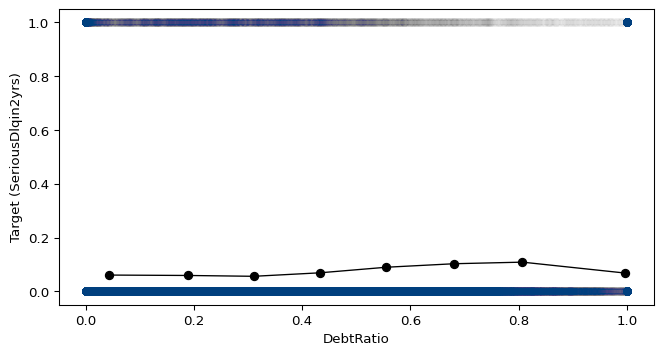

(a) Datos observados

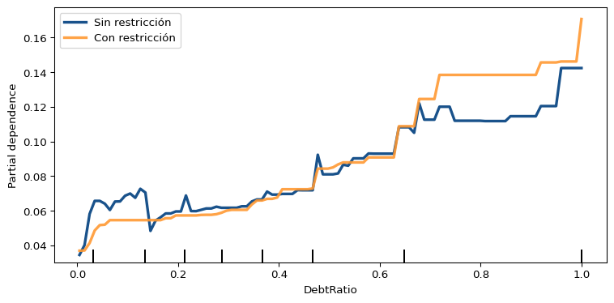

(b) Dependencia parcial

Figura 11: Comparación de modelos con y sin restricción monotónica

## 4.6 Simulación de cambio en DebtRatio

Se obtiene una observación de X:

| DebtRatio | age | MonthlyIncome | NumberOfOpenCreditLinesAndLoans |
| --- | --- | --- | --- |
| 0.1 | 57 | 10121.0 | 7 |

Se incrementa su `DebtRatio` de 0.1 a 0.15. El modelo restringido mantiene el sentido esperado del cambio: un aumento en `DebtRatio` no puede producir una reducción de la probabilidad de *default*.

Tabla 6: Variación en la probabilidad al variar DebtRatio, manteniendo el resto de las variables constantes

| Modelo | P(default) |  | △ % |  |
| --- | --- | --- | --- | --- |
|  | DebtRatio = 0.1 | DebtRatio = 0.15 |  |  |
| Sin restricción | 2.42% | 2.10% |  | −0.32% |
| Con restricción | 1.74% | 1.74% | 0.00% |  |

## 4.7 Human in the loop

Las restricciones monotónicas muestran una idea más amplia: **la supervisión humana no termina cuando el modelo empieza a predecir**.

En el contexto actual de la inteligencia artificial, no alcanza con preguntar si un sistema es preciso. También debemos preguntarnos:

> ¿Es consistente con lo que sabemos, podemos explicar sus decisiones y quién responde cuando se equivoca?

La IA puede ampliar nuestras capacidades, pero las decisiones con impacto requieren **criterio humano, controles y responsabilidad**.

## 4.8 Referencias / Recursos

Andrei. 2026. «The Mathematics Behind Gradient Boosting and Ensembles». https://datalad.co.uk/the-mathematics-behind-gradient-boosting-and-ensembles/.

Fusion, Credit, y Will Cukierski. 2011. «Give Me Some Credit». https://kaggle.com/competitions/GiveMeSomeCredit.

Gunning, David, y David Aha. 2019. «DARPA’s explainable artificial intelligence (XAI) program». *AI Magazine* 40 (2): 44-58. https://doi.org/10.1609/aimag.v40i2.2850.

Hastie, Trevor, Robert Tibshirani, y Jerome Friedman. 2009. *The Elements of Statistical Learning: Data Mining, Inference, and Prediction*. 2.ª ed. Springer Series en Statistics. New York, NY: Springer. https://doi.org/10.1007/978-0-387-84858-7.

James, Gareth, Daniela Witten, Trevor Hastie, Robert Tibshirani, y Jonathan Taylor. 2023. *An Introduction to Statistical Learning with Applications in Python*. Springer Texts en Statistics. Springer. https://doi.org/10.1007/978-3-031-38747-0.

Molnar, Christoph. 2025. *Interpretable Machine Learning: A Guide for Making Black Box Models Explainable*. 3.ª ed. https://christophm.github.io/interpretable-ml-book.

## 4.9 Contacto

[karinabartolome](https://www.linkedin.com/in/karinabartolome/)

karbartolome

karbartolome

[Workshops](https://karbartolome.github.io/workshops/)

[Blog](https://karbartolome-blog.netlify.app/)

[figure not shown]

Cimbage - IADCOM | Facultad de Ciencias Económicas - UBA | [Workshops](https://karbartolome.github.io/workshops/)